# Basketball Project

Jamie Doyle and Kelly Rivera

4/30/2022

# Importing Basketball Data

Data is from: https://www.kaggle.com/datasets/andrewsundberg/college-basketball-dataset Years 2013 - 2019 (Division I college basketball seasons) This dataset contains 25 variables Variables used for identifying: TEAM, and YEAR The CSV file being read in had variable names changed when they started with a number. Example: 2P_O was renamed to P2_O

```r
cbb <- read_csv("cbb.csv")
#head(cbb)
```

# Initial Variable Selection

Note: MASS and dplyr package cause ‘select issues’

[output not shown]

[figure not shown]

```r
cols <- cbb %>%
  dplyr::select(W, ADJOE, ADJDE, P2_D, P2_O, EFG_D, EFG_O, BARTHAG, WAB)

col.cor <- cor(cols)
corrplot(col.cor, tl.pos = 'd', cl.pos = 'n', method = 'square', addCoef.col = 'black', type = 'lower')
```

# Model Formulation (1): BARTHAG

```r
reg.out <- lm(W~ADJOE+ADJDE+BARTHAG+EFG_O+EFG_D+P2_O+P2_D,data=cbb)
summary(reg.out)
```

```
Call:
lm(formula = W ~ ADJOE + ADJDE + BARTHAG + EFG_O + EFG_D + P2_O +
    P2_D, data = cbb)

Residuals:
     Min       1Q   Median       3Q      Max
-10.9046  -2.1785  -0.0594   2.1238  10.5124

Coefficients:
            Estimate Std. Error t value Pr(>|t|)
(Intercept) 12.59318    2.07162   6.079 1.40e-09 ***
ADJOE        0.32344    0.03461   9.345  < 2e-16 ***
ADJDE       -0.29438    0.03595  -8.188 4.21e-16 ***
BARTHAG     -0.89225    1.48477  -0.601  0.54794
EFG_O        0.47036    0.05334   8.818  < 2e-16 ***
EFG_D       -0.89289    0.06075 -14.697  < 2e-16 ***
P2_O         0.13463    0.04340   3.102  0.00194 **
P2_D         0.32219    0.04749   6.785 1.45e-11 ***
---
Signif. codes:  0 ‘***’ 0.001 ‘**’ 0.01 ‘*’ 0.05 ‘.’ 0.1 ‘ ’ 1

Residual standard error: 3.153 on 2447 degrees of freedom
Multiple R-squared:  0.7732,    Adjusted R-squared:  0.7726
F-statistic:  1192 on 7 and 2447 DF,  p-value: < 2.2e-16
```

Barthag variable is clearly not significant to the model

# Model Formulation (2): Check for Transformations

```r
par(mfrow=c(3,3))
hist(cbb$ADJOE, xlab="ADJOE", main=NULL)
hist(cbb$ADJDE, xlab="ADJDE", main=NULL)
```

```r
hist(cbb$P2_O, xlab="P2_O", main=NULL)
hist(cbb$P2_D, xlab="P2_D", main=NULL)
```

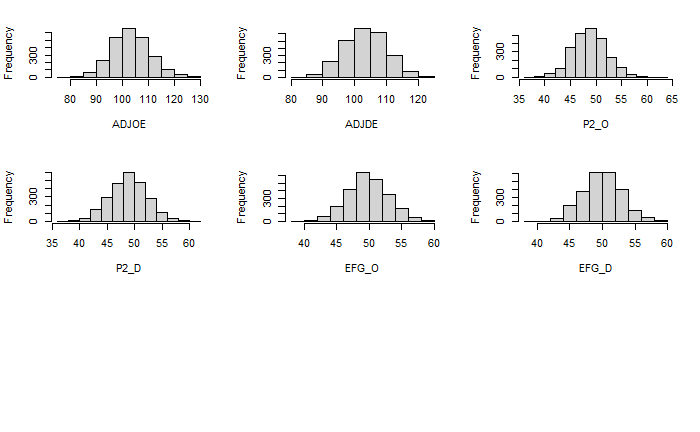

```r
hist(cbb$EFG_O, xlab="EFG_O", main=NULL)
hist(cbb$EFG_D, xlab="EFG_D", main=NULL)
```

```r
#hist(cbb$BARTHAG, xlab="BARTHAG", main=NULL)
```

# Model Formulation (3): Check for Outliers Graphically

```r
reg1 <- lm(W~ADJOE, data = cbb)
reg2 <- lm(W~ADJDE, data = cbb)
reg3 <- lm(W~P2_O, data = cbb)
reg4 <- lm(W~P2_D, data = cbb)
reg5 <- lm(W~EFG_O, data = cbb)
reg6 <- lm(W~EFG_D, data = cbb)

par(mfrow=c(3,3))

#Add axis labels
plot(reg1, which = 1)
plot(reg2, which = 1)
```

```r
plot(reg3, which = 1)
plot(reg4, which = 1)
```

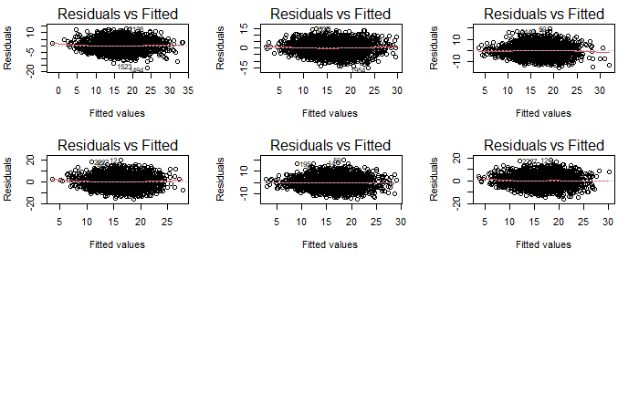

```r
plot(reg5, which = 1)
plot(reg6, which = 1)
```

# Model Formulation (4): Multicollinearity with VIF

```r
# Regresses on all variables
glm_BARTHAG <- lm(W ~ADJDE+ADJOE+P2_O+P2_D+EFG_O+EFG_D+BARTHAG, data=cbb)
finalGLM <- lm(W~ADJDE+ADJOE+P2_O+P2_D+EFG_O+EFG_D, data=cbb)
noEFG_D <- lm(W~ADJDE+ADJOE+P2_O+P2_D+EFG_O, data=cbb)

# VIFS comparitions                              # Computes VIF-value
vif(glm_BARTHAG)
```

```
    ADJDE     ADJOE      P2_O      P2_D     EFG_O     EFG_D   BARTHAG
13.922108 16.095013  5.326692  6.212293  6.938721  7.873914 35.737528
```

```r
vif(finalGLM)
```

```
   ADJDE    ADJOE     P2_O     P2_D    EFG_O    EFG_D
3.531022 3.032806 5.321541 6.210512 6.922742 7.865444
```

```r
vif(noEFG_D)
```

```
   ADJDE    ADJOE     P2_O     P2_D    EFG_O
2.792876 2.972320 5.321143 2.225735 6.914937
```

# Variable Selection (1)

```r
ols_step_backward_p(finalGLM, prem = 0.05)
```

```
[1] "No variables have been removed from the model."
```

# Model Diagnostics (1): Check Assumptions

Linearity and Homogeneous Variance

```r
reg1 <- lm(W~ADJOE, data = cbb)
reg2 <- lm(W~ADJDE, data = cbb)
reg3 <- lm(W~P2_O, data = cbb)
reg4 <- lm(W~P2_D, data = cbb)
reg5 <- lm(W~EFG_O, data = cbb)
reg6 <- lm(W~EFG_D, data = cbb)

par(mfrow=c(3,3))

#Add axis labels
plot(reg1, which = 1)
plot(reg2, which = 1)
```

```r
plot(reg3, which = 1)
plot(reg4, which = 1)
```

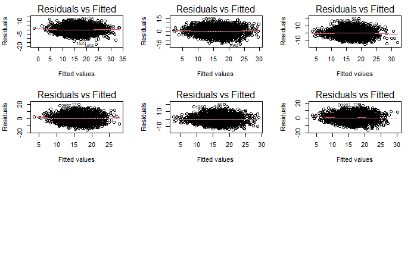

```r
plot(reg5, which = 1)
plot(reg6, which = 1)
```

# Model Diagnostics (2): Check Assumptions

```r
reg10 <- lm(W~ADJOE, data = cbb)
reg11 <- lm(W~ADJDE, data = cbb)
reg12 <- lm(W~P2_O, data = cbb)
reg13 <- lm(W~P2_D, data = cbb)
reg14 <- lm(W~EFG_O, data = cbb)
reg15 <- lm(W~EFG_D, data = cbb)

par(mfrow=c(3,3))

qqnorm(reg10$resid,ylab="Residuals",xlab= # Normal quantile plot
  "ADJOE",cex.lab=1.6,cex.axis=
  1.5,cex=1.5,main=" ",
  cex.main=1.8,pch=16,mgp=c(2.7,1,0))
qqnorm(reg11$resid,ylab="Residuals",xlab= # Normal quantile plot
  "ADJDE",cex.lab=1.6,cex.axis=
  1.5,cex=1.5,main=" ",
  cex.main=1.8,pch=16,mgp=c(2.7,1,0))
```

```r
qqnorm(reg12$resid,ylab="Residuals",xlab= # Normal quantile plot
  "P2_O",cex.lab=1.6,cex.axis=
  1.5,cex=1.5,main=" ",
  cex.main=1.8,pch=16,mgp=c(2.7,1,0))
qqnorm(reg13$resid,ylab="Residuals",xlab= # Normal quantile plot
  "P2_D",cex.lab=1.6,cex.axis=
  1.5,cex=1.5,main=" ",
  cex.main=1.8,pch=16,mgp=c(2.7,1,0))
```

```r
qqnorm(reg14$resid,ylab="Residuals",xlab= # Normal quantile plot
  "EFG_O",cex.lab=1.6,cex.axis=
  1.5,cex=1.5,main=" ",
  cex.main=1.8,pch=16,mgp=c(2.7,1,0))
qqnorm(reg14$resid,ylab="Residuals",xlab= # Normal quantile plot
  "EFG_D",cex.lab=1.6,cex.axis=
  1.5,cex=1.5,main=" ",
  cex.main=1.8,pch=16,mgp=c(2.7,1,0))
```

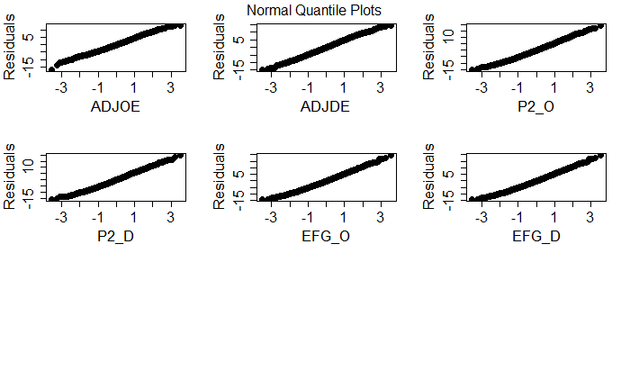

```r
mtext("Normal Quantile Plots", side = 3, line = -1.5, outer = TRUE)
```

```r
reg <- lm(W~ADJDE+ADJOE+P2_O+P2_D+EFG_O+EFG_D, data = cbb)
sf.test(reg$resid)            # Conducts Shapiro-Francia test
```

```
    Shapiro-Francia normality test

data:  reg$resid
W = 0.99899, p-value = 0.1518
```

# Model Diagnostics (3): F-Test for Model Significance

```r
summary(finalGLM)
```

```
Call:
lm(formula = W ~ ADJDE + ADJOE + P2_O + P2_D + EFG_O + EFG_D,
    data = cbb)

Residuals:
     Min       1Q   Median       3Q      Max
-10.9298  -2.1789  -0.0559   2.1330  10.4701

Coefficients:
            Estimate Std. Error t value Pr(>|t|)
(Intercept) 12.08673    1.89220   6.388 2.01e-10 ***
ADJDE       -0.27572    0.01810 -15.230  < 2e-16 ***
ADJOE        0.30470    0.01502  20.283  < 2e-16 ***
P2_O         0.13381    0.04337   3.085  0.00206 **
P2_D         0.32170    0.04747   6.777 1.54e-11 ***
EFG_O        0.47189    0.05327   8.859  < 2e-16 ***
EFG_D       -0.89169    0.06071 -14.687  < 2e-16 ***
---
Signif. codes:  0 ‘***’ 0.001 ‘**’ 0.01 ‘*’ 0.05 ‘.’ 0.1 ‘ ’ 1

Residual standard error: 3.152 on 2448 degrees of freedom
Multiple R-squared:  0.7732,    Adjusted R-squared:  0.7726
F-statistic:  1391 on 6 and 2448 DF,  p-value: < 2.2e-16
```

# Inferential Results (1): Residual Statistics

```r
reg <- lm(W~ADJDE+ADJOE+P2_O+P2_D+EFG_O+EFG_D, data = cbb)
crit_value <- abs(qt(p=.025, df=2447, lower.tail=TRUE))
crit_value
```

```
[1] 1.960934
```

```r
reg <- lm(W~ADJDE+ADJOE+P2_O+P2_D+EFG_O+EFG_D, data = cbb)
jack <- rstudent(reg)               # Computes studentized deleted residuals
jacka <- data.frame(t(data.frame(as.list(abs(jack)))))
jack2a <- jacka %>%
  rename(COL1 = 1)
jack_count <- jack2a %>% filter(COL1 > crit_value)
count(jack_count)
```

| n |
| --- |
| 119 |

```r
#leverages
lev1 <- hatvalues(reg)
lev_crit = (2*(7/2455))
lev2 <- data.frame(t(data.frame(as.list(lev1))))
lev3 <- lev2 %>%
  rename(COL2 = 1)
both1 <- cbind(jack2a, lev3)
both2 <- both1 %>% filter(COL1 > crit_value, COL2 > lev_crit)
count(both2)
```

| n |
| --- |
| 5 |

```r
NA
```

# Inferential Results (2): Influential Statistics

```r
reg <- lm(W~ADJDE+ADJOE+P2_O+P2_D+EFG_O+EFG_D, data = cbb)

#cook's d
vec1 <- cooks.distance(reg)
cookd <- data.frame(t(data.frame(as.list(vec1))))
cookd1 <- cookd %>%
  rename(COOKD = 1)
cookd2 <- cookd1 %>%
  filter(COOKD > 1)
count(cookd2)
```

| n |
| --- |
| 0 |

```r
#dffits
vec2 <- dffits(reg)
dffit <- data.frame(t(data.frame(as.list(vec2))))
df_crit = 2*sqrt(7/2455)
df_crit
```

```
[1] 0.1067956
```

```r
dffit1 <- dffit %>%
  rename(DFFit = 1)
dffit2 <- dffit1 %>%
  filter(abs(DFFit) > df_crit)
count(dffit2)
```

| n |
| --- |
| 120 |

```r
#dfbetas
vec3 <- dfbetas(reg)
beta_crit = (2/sqrt(2455))
beta_crit
```

```
[1] 0.04036493
```

```r
dfbeta1 <- data.frame(vec3)

dfbeta2_1 <- dfbeta1 %>%
  filter(abs(X.Intercept.) > beta_crit)
count(dfbeta2_1)
```

| n |
| --- |
| 145 |

```r
dfbeta2_2 <- dfbeta1 %>%
  filter(abs(ADJDE) > beta_crit)
count(dfbeta2_2)
```

| n |
| --- |
| 142 |

```r
dfbeta2_3 <- dfbeta1 %>%
  filter(abs(ADJOE) > beta_crit)
count(dfbeta2_3)
```

| n |
| --- |
| 132 |

```r
dfbeta2_4 <- dfbeta1 %>%
  filter(abs(P2_O) > beta_crit)
count(dfbeta2_4)
```

| n |
| --- |
| 170 |

```r
dfbeta2_5 <- dfbeta1 %>%
  filter(abs(P2_D) > beta_crit)
count(dfbeta2_5)
```

| n |
| --- |
| 155 |

```r
dfbeta2_6 <- dfbeta1 %>%
  filter(abs(EFG_O) > beta_crit)
count(dfbeta2_6)
```

| n |
| --- |
| 167 |

```r
dfbeta2_7 <- dfbeta1 %>%
  filter(abs(EFG_D) > beta_crit)
count(dfbeta2_7)
```

| n |
| --- |
| 144 |

```r
#plot(reg)
```

# Inferential Results (3): Robust Regression

Robust Regression vs. GLM

```r
fit.bisq<-rlm(W~ADJDE+ADJOE+P2_O+P2_D+EFG_O+EFG_D,data=cbb, psi=psi.bisquare)
summary(fit.bisq)
```

```
Call: rlm(formula = W ~ ADJDE + ADJOE + P2_O + P2_D + EFG_O + EFG_D,
    data = cbb, psi = psi.bisquare)
Residuals:
      Min        1Q    Median        3Q       Max
-10.93526  -2.14224  -0.02671   2.16186  10.53242

Coefficients:
            Value    Std. Error t value
(Intercept)  11.7211   1.9553     5.9944
ADJDE        -0.2692   0.0187   -14.3926
ADJOE         0.3058   0.0155    19.6967
P2_O          0.1362   0.0448     3.0392
P2_D          0.3294   0.0491     6.7138
EFG_O         0.4743   0.0550     8.6155
EFG_D        -0.9127   0.0627   -14.5478

Residual standard error: 3.196 on 2448 degrees of freedom
```

```r
reg2.out <- lm(W~ADJDE+ADJOE+P2_O+P2_D+EFG_O+EFG_D,data=cbb)
summary(reg2.out)
```

```
Call:
lm(formula = W ~ ADJDE + ADJOE + P2_O + P2_D + EFG_O + EFG_D,
    data = cbb)

Residuals:
     Min       1Q   Median       3Q      Max
-10.9298  -2.1789  -0.0559   2.1330  10.4701

Coefficients:
            Estimate Std. Error t value Pr(>|t|)
(Intercept) 12.08673    1.89220   6.388 2.01e-10 ***
ADJDE       -0.27572    0.01810 -15.230  < 2e-16 ***
ADJOE        0.30470    0.01502  20.283  < 2e-16 ***
P2_O         0.13381    0.04337   3.085  0.00206 **
P2_D         0.32170    0.04747   6.777 1.54e-11 ***
EFG_O        0.47189    0.05327   8.859  < 2e-16 ***
EFG_D       -0.89169    0.06071 -14.687  < 2e-16 ***
---
Signif. codes:  0 ‘***’ 0.001 ‘**’ 0.01 ‘*’ 0.05 ‘.’ 0.1 ‘ ’ 1

Residual standard error: 3.152 on 2448 degrees of freedom
Multiple R-squared:  0.7732,    Adjusted R-squared:  0.7726
F-statistic:  1391 on 6 and 2448 DF,  p-value: < 2.2e-16
```

# Comparing Model Performance: GLM, Ridge, PCR

GLM, PRESS - leave one out

```r
pressGLM <- ols_press(finalGLM)                                  # getting press to calc the CV error to compare with

glmCV <- pressGLM/2455                      # getting the CV error, cv= PRESS/n,   n=sample size
```

CV for Ridge and PCR

```r
attach(cbb)
x<-cbind(ADJDE,ADJOE,P2_O,P2_D,EFG_O, EFG_D, BARTHAG)
y<-W

grid <- seq(0.001,.5,length = 100)

# Ridge reg model
ridge.mod=cv.glmnet(x,y,lambda = grid, nfold=length(y), alpha=0)
lambda=ridge.mod$lambda.min                                         # min lambda value from model

predict(ridge.mod,s=lambda, type="coefficients")
```

```
8 x 1 sparse Matrix of class "dgCMatrix"
                    s1
(Intercept) 12.2860554
ADJDE       -0.2835326
ADJOE        0.3113940
P2_O         0.1353457
P2_D         0.3156710
EFG_O        0.4705615
EFG_D       -0.8841283
BARTHAG     -0.3529442
```

```r
# CV of Ridge
ridgeCV <- min(ridge.mod$cvm)

# PCR model
pr.out = prcomp(x,scale=TRUE)
pcreg<- lm(W~pr.out$x[,1:4])

# ?????Confirm what variables to use - doesn't seem to help
pcr.cv = pcr(W~ADJDE+ADJOE+P2_O+P2_D+EFG_O+EFG_D+BARTHAG, data =cbb, scale= T, validation = "LOO")
summary(pcr.cv)
```

```
Data:   X dimension: 2455 7
    Y dimension: 2455 1
Fit method: svdpc
Number of components considered: 7

VALIDATION: RMSEP
Cross-validated using 2455 leave-one-out segments.
       (Intercept)  1 comps  2 comps  3 comps  4 comps  5 comps  6 comps  7 comps
CV           6.612    3.315    3.263    3.255    3.253     3.22    3.168    3.158
adjCV        6.612    3.315    3.263    3.255    3.253     3.22    3.168    3.158

TRAINING: % variance explained
   1 comps  2 comps  3 comps  4 comps  5 comps  6 comps  7 comps
X    58.20    87.26    94.25    97.45    98.69    99.76   100.00
W    74.88    75.68    75.82    75.87    76.38    77.15    77.32
```

```r
pr.var=pr.out$sdev^2
pve= pr.var/sum(pr.var)

# plot(pve, xlab = "Principal Comp", ylab="Prop of Varianve Explained", ylim=c(0,1), type="b")
# plot(cumsum(pve), xlab = "Principal Comp", ylab="Cumulative Prop of Varianve Explained", ylim=c(0,1), type="b")

# CV from PCR (worst)
pcrCV <- (3.158)^2
```

We are going to note that although the pcr was supposed to minimize the multicollinearity problem it failed to do so, addtionally the pcr model with the lowest cv error was also the model that had the most components which is odd.

## Comparing the CV errors of GLM, Ridge, and PCR models

```r
cvErrors <- cbind(glmCV, ridgeCV, pcrCV)
cvErrors
```

```
        glmCV  ridgeCV    pcrCV
[1,] 9.964202 9.970882 9.972964
```

# Check for multicollinearity with new (reduced) model

```r
cbb_red2 <- select(cbb, c(W, ADJOE, ADJDE, P2_O, P2_D, EFG_O, EFG_D))
pairs.panels(cbb_red2[,1:7])

reg9 <- lm(W ~ ADJDE+ADJOE+P2_O+P2_D+EFG_O+EFG_D,data=cbb) # Regresses on all variables
vif(reg9)                              # Computes VIF-values
```

[output not shown]

# Not added in paper or presentation, but used during working on project:

## BARTHAG violating assumptions

[figure not shown]

```r
cbb_test <- cbb %>%
  mutate(BARTHAG2 = sqrt(BARTHAG))

plot(cbb_test$W,cbb$BARTHAG,pch=16,  # Plots mortality vs. wine
  xlab="Power Rating (Chance of beating an average Division I team)", #   consumption with axis labels
  cex.lab=1.6,cex.axis=1.5,cex=1.5,      #   and a title
  ylab="Number of Games Won",
  main="Power Rating VS. Number of Games Won",
  cex.main=1.8,mgp=c(2.7,1,0))
```

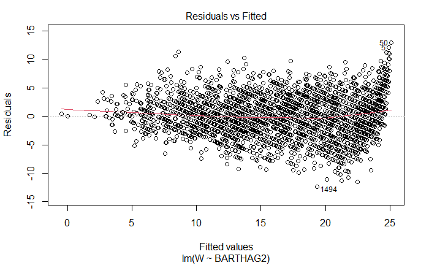

```r
reg5 <- lm(W~BARTHAG2, data = cbb_test)
plot(reg5, which = 1)
```

# Interaction Terms check

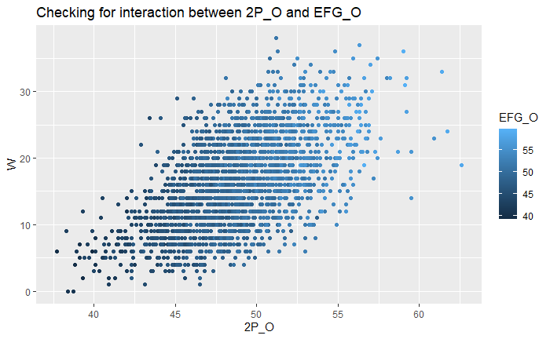

```r
ggplot(cbb) +
  geom_point(aes(y=W, x=P2_O, color=EFG_O)) +
  labs(title="Checking for interaction between 2P_O and EFG_O",
       x= "2P_O")
```

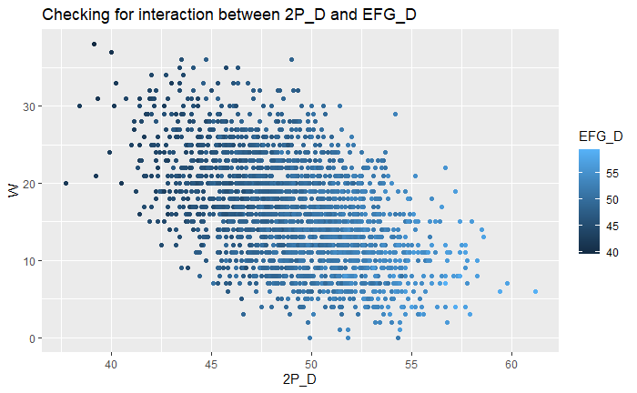

```r
ggplot(cbb) +
  geom_point(aes(y=W, x=P2_D, color=EFG_D)) +
  labs(title="Checking for interaction between 2P_D and EFG_D",
       x= "2P_D")
```

## Checking Interaction Significance

```r
interMod <- lm(W~ADJDE+ADJOE+P2_O+P2_D+EFG_O+EFG_D+P2_O*EFG_O+P2_D*EFG_D, data = cbb)

summary(interMod)
```

```
Call:
lm(formula = W ~ ADJDE + ADJOE + P2_O + P2_D + EFG_O + EFG_D +
    P2_O * EFG_O + P2_D * EFG_D, data = cbb)

Residuals:
     Min       1Q   Median       3Q      Max
-10.8390  -2.1611  -0.0667   2.1231  10.5796

Coefficients:
             Estimate Std. Error t value Pr(>|t|)
(Intercept) 48.083426  16.064570   2.993  0.00279 **
ADJDE       -0.275937   0.018088 -15.256  < 2e-16 ***
ADJOE        0.303411   0.015037  20.178  < 2e-16 ***
P2_O         0.014355   0.219629   0.065  0.94789
P2_D        -0.301132   0.249402  -1.207  0.22739
EFG_O        0.357218   0.213880   1.670  0.09501 .
EFG_D       -1.492312   0.244951  -6.092 1.29e-09 ***
P2_O:EFG_O   0.002392   0.004271   0.560  0.57551
P2_D:EFG_D   0.012369   0.004872   2.539  0.01119 *
---
Signif. codes:  0 ‘***’ 0.001 ‘**’ 0.01 ‘*’ 0.05 ‘.’ 0.1 ‘ ’ 1

Residual standard error: 3.149 on 2446 degrees of freedom
Multiple R-squared:  0.7738,    Adjusted R-squared:  0.7731
F-statistic:  1046 on 8 and 2446 DF,  p-value: < 2.2e-16
```